# Подготовка параметров пользователя Трипадвизора. Итерация 3

Alexey Shovkun

Saturday, June 13, 2015

В рамках данной итерации мы уйдем от процентной нормализации для некоторых параметров в пользу гиперболического тангенса.

## Формирование таблицы параметров пользователя

Целесообразно иметь код с подготовкой таблицы параметров пользователя в одном месте, поэтому в данном файле мы возьмем исходные ненормализованные данные о пользователях, обогатим их данными о посещении ВИП и не-ВИП мест, и затем проведем нормализацию всех параметров. Алгоритм нормализации в основном будет повторять алгоритм, использованный при первой итерации обучения (см. edaMOMos.Rmd).

На основе данных об отзывах пользователя о месте (MembersCityPage) посчитаем следующие параметры:

- **VIPBalanceCount** - разница между количеством посещенных VIP и не-VIP мест. Нормализуем с помощью гиперболического тангенса.

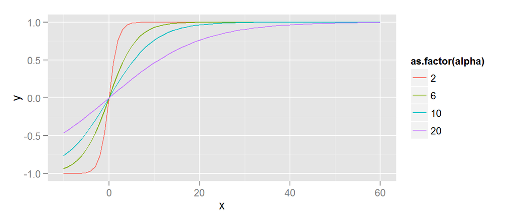

Нормализация гиперболическим тангенсом дает нам значения в диапазоне (-1,1), сохраняя 0, т.е. если изначально значение было равно 0, то после нормализации оно также будет равно 0.

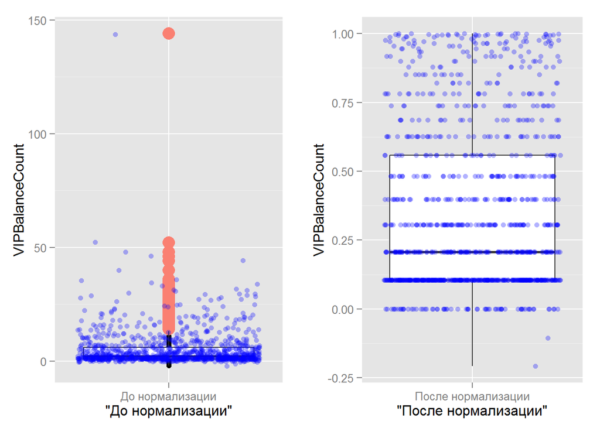

Также “растягиваем” шкалу нормализации таким образом, чтобы среднее значений **VIPBalanceCount**, равной **5.2223301**, после нормализации была равна 0,5. Тогда значения, близкие к среднему будут хорошо различимы между собой, а высокие значения “схлопнутся” в районе +1. См. график ниже.

Добавим параметры, вычисленные на основе отзывов о местах:

- **categoty*** - нормализованное гиперболическим тангенсом количество отзывов об 1-5 звездных местах.
- **userRating*** - нормализованное гиперболическим тангенсом количество отзывов о местах c пользовательским рейтингом 1-5.
- **categoty*Percent** - доля отзывов об 1-5 звездных местах от общего числа отзывов.
- **userRating*Percent** - доля отзывов о местах c пользовательским рейтингом 1-5 от общего числа отзывов.

Коэффициент нормализации подбираем так, чтобы четко различались до ~30 отзывов.

Обогащаем таблицу параметров со страницы MemberOverlay параметрами с главной стрницы пользователя:

- **citiesCount** - количество посещенных городов, поскольку его значение, указанное на странице MemberOverlay, не вызывает доверие.
- **publicationsCount** - берем данные с главной страницы, а если их нет, то с MemberOverlay.
- **countriesCount** - количество посеценных стран.
- **badge*Count** - количественные показатели активности и полезности пользователя.
- **badgeTotalReviewsTitle** - титул пользователя, заменяем взятый из MemberOVerlay.
- **travelStatDistance** - количество преодаленных километров.
- **travelStatWorldPercent** - какая часть мира посещена (проценты).
- **tagsList** - список предпочитаемых видов отдыха, заменяем взятый из MemberOVerlay.

Добавим параметры интенсивности (за год):

- **VIPBPYCount** - средняя за год разница между количеством посещенных VIP и не-VIP мест.

И проводим подготовку остальных параметров из таблицы MemberOverlay также, как и на прошлой итерации обучения модели.

Переводим в долю от общего кол-во отзывов данного пользователя. Поскольку параметры reviews*Count парсились со страницы MemberOverlay, а параметр badgeTotalReviewsCount парсился с главной страницы пользователя и между ними есть разрыв во времени, то для корректного вычисления процента, в знаменателе используем сумму reviews*Count. Несмотря на назвыание Percent, сразу считаем долю в диапазоне [0,1], т.к. все процентные параметры все равно быдем далее линейно нормализовывать в этот диапазон

## Разведочный анализ

Проанализируем визуально параметры пользователя.

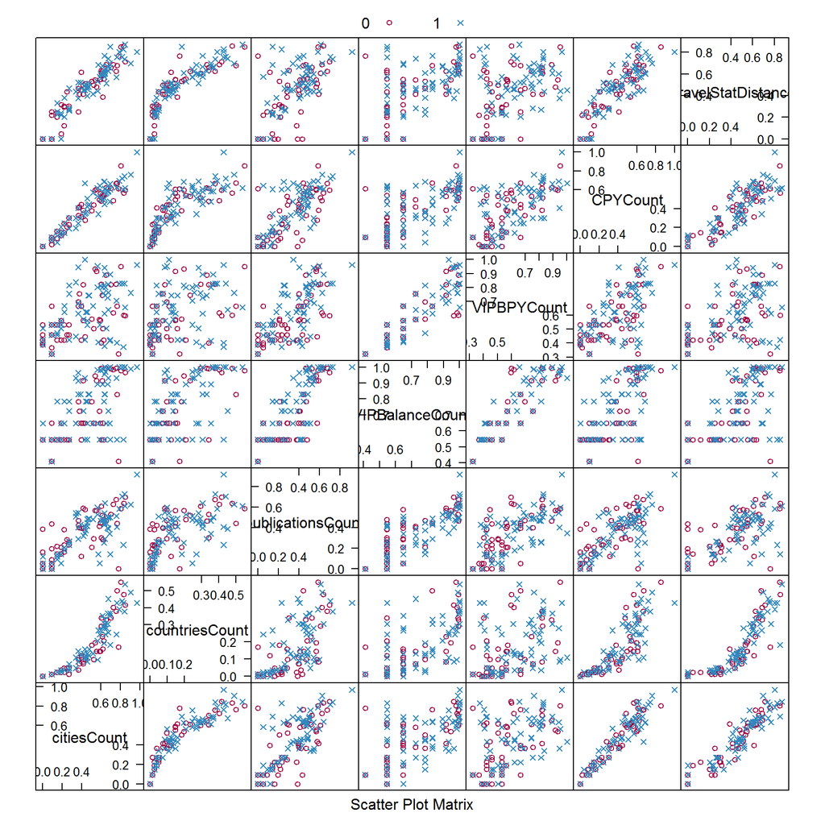

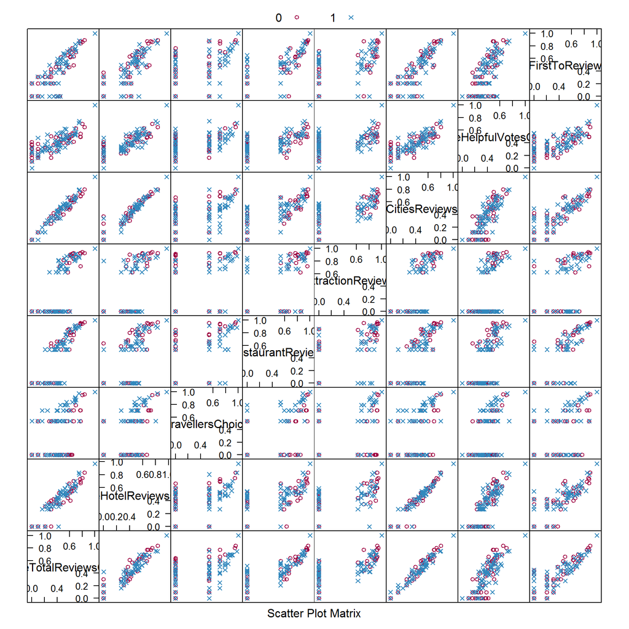

Графики выше показывают, что интересующие нас классы пользователей (ВИП/не-ВИП) все еще сильно смешаны между собой.

Процентные показатели:

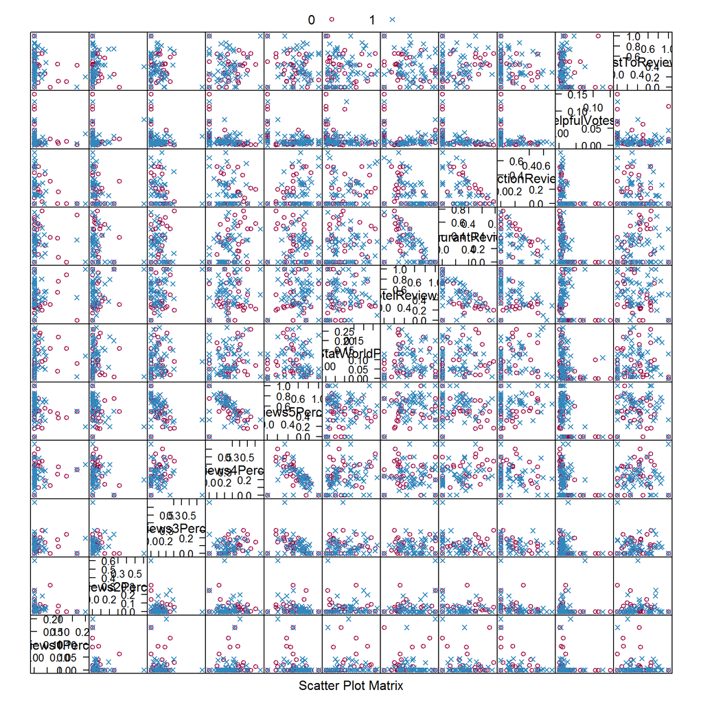

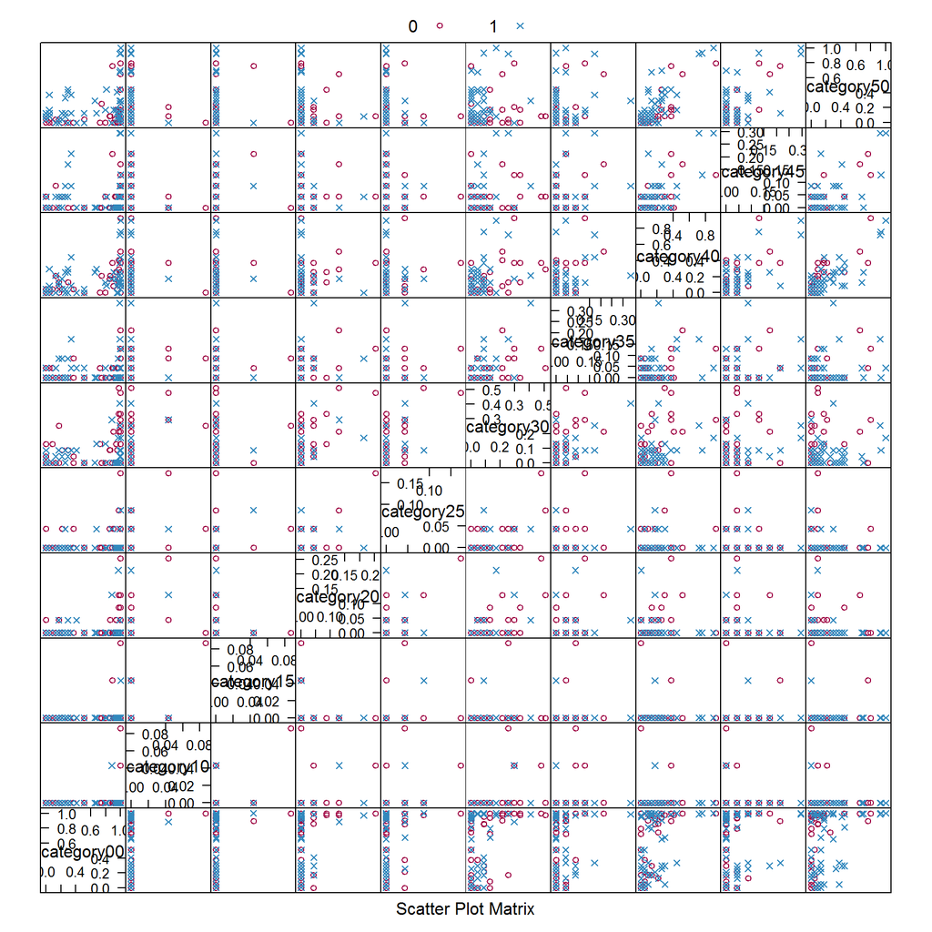

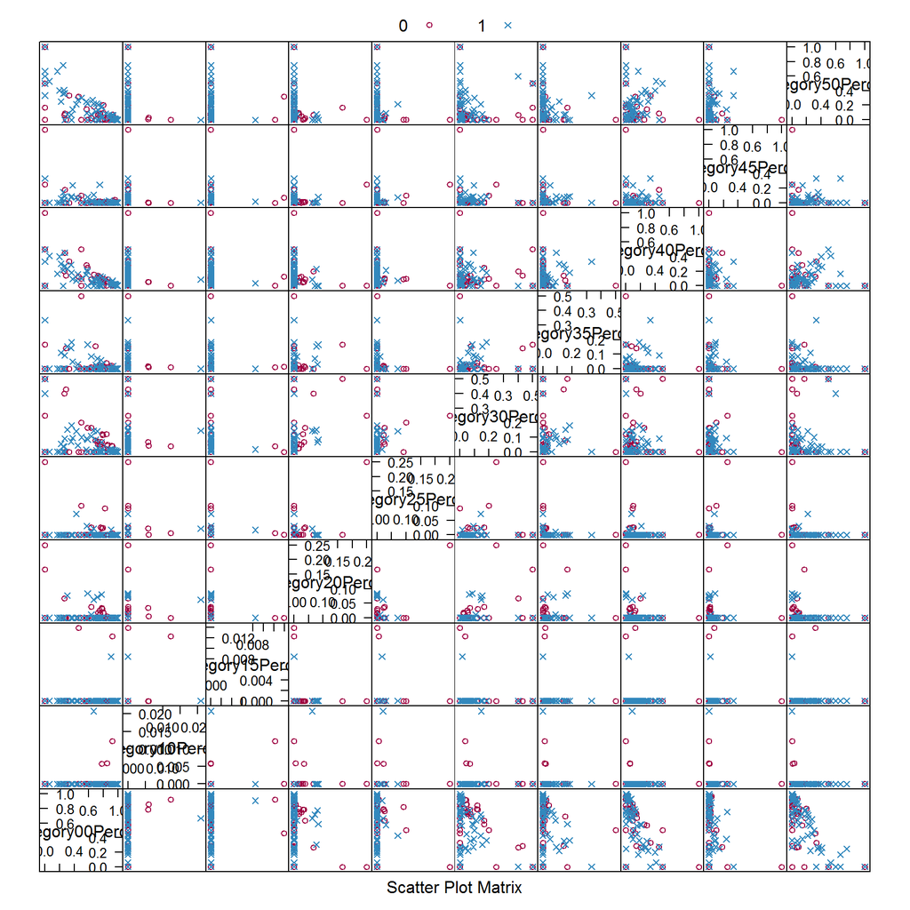

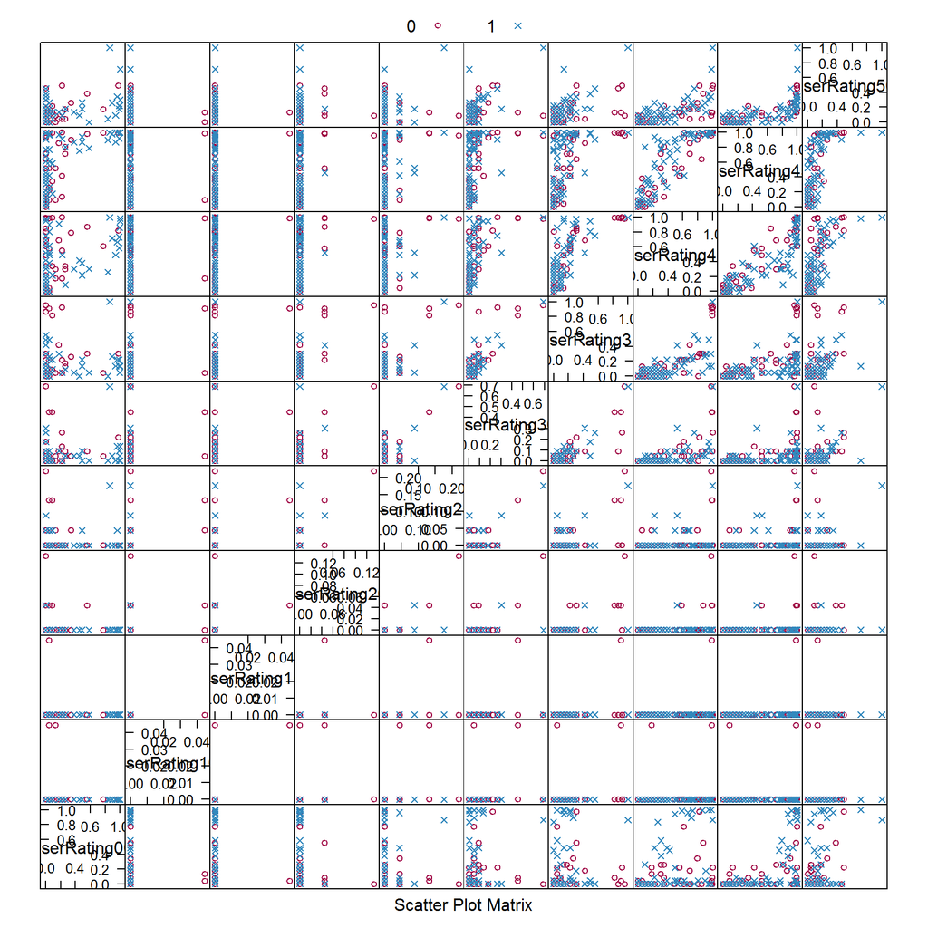

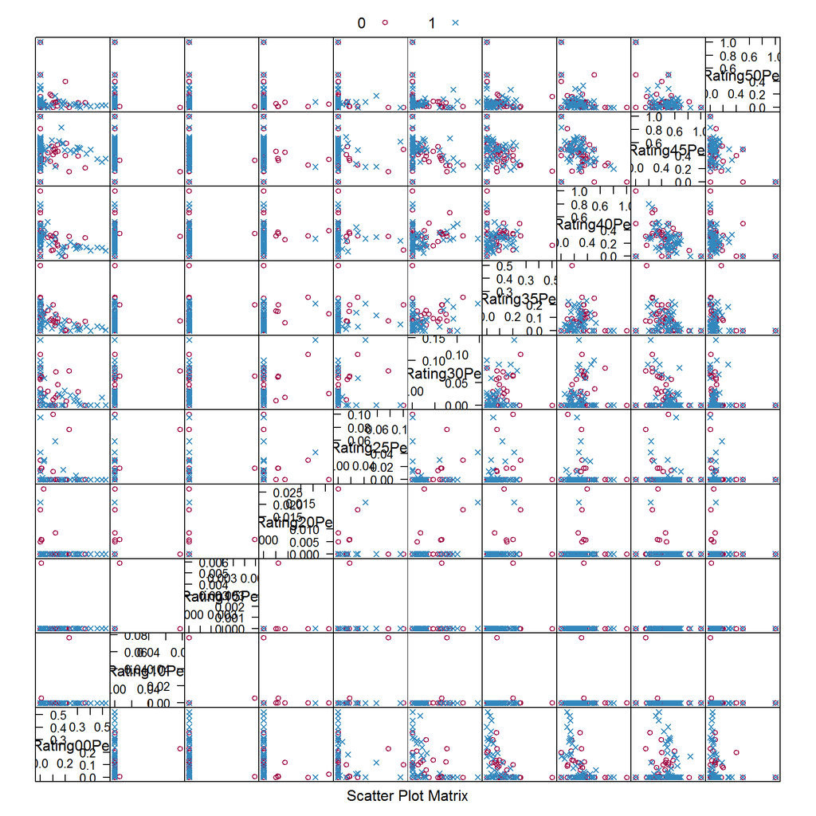

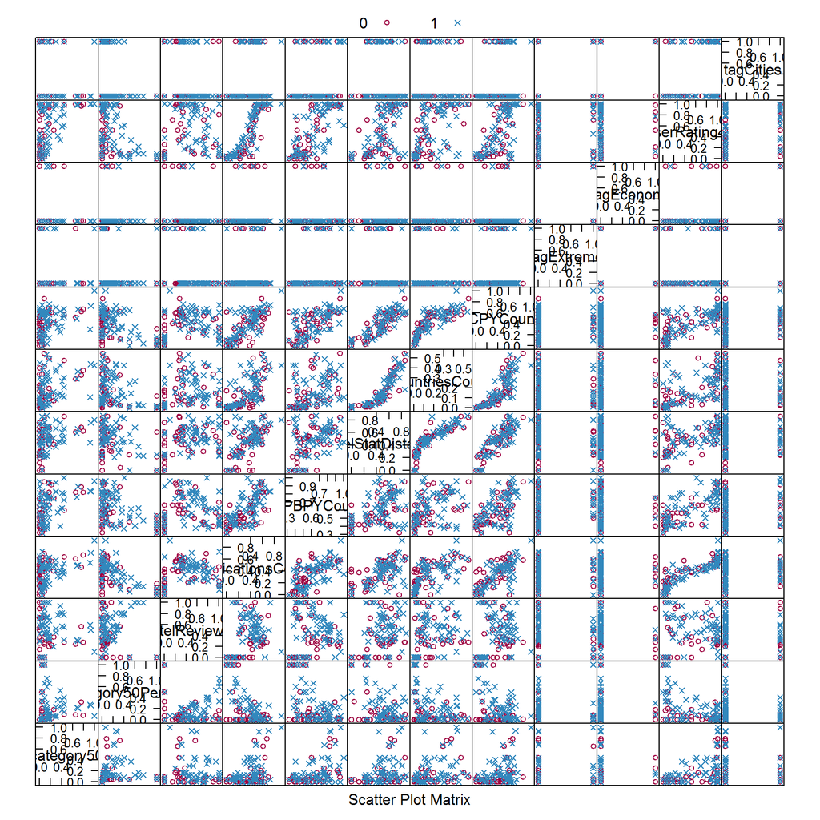

### Количество посещенных VIP мест

- **VIPBalanceCount** - разница между количеством посещенных ВИП и не-ВИП мест.
- **VIPBPYCount** - то же зсамое, но в среднем за год. Умозрительно ожидается, что этот параметр более показательный и честный.

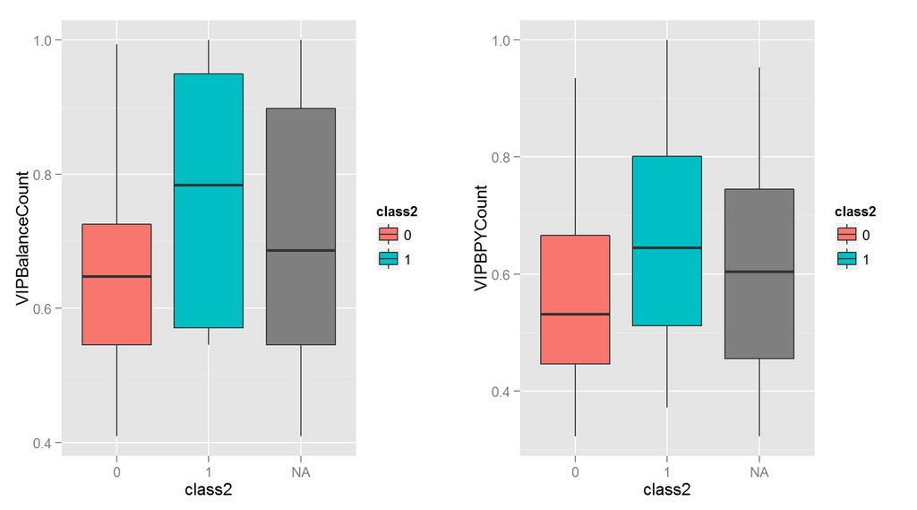

К сожалению, из графиков видим, что параметры посещения ВИП и не-ВИП мест не сильно выделяют класс ВИП пользователей.

### Параметры Пол и Возраст

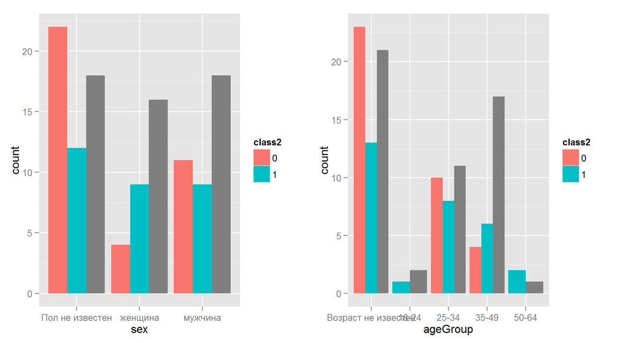